# Overview

### Main Functions

```python
### Feature Engineering & Date Cleaning (reviews) functions ###

def _extract_ratings(text_ls):
    """
    Extract Ratings from reviews_list and taking average
    """
    try:
        rate_ls = ast.literal_eval(text_ls)
        rate_ls = [float(x[0].lower().replace("rated","").strip()) for x in rate_ls]
        final_rating = np.average(rate_ls)
        return np.round(final_rating,1)
    except Exception as e:
        return np.nan

def _extract_reviews(row):
    """
    Extract Reviews Text from reviews_list
    """
    try:
        text_ls = row["reviews_list"]
        review_ls = ast.literal_eval(text_ls)
        if len(review_ls) > 0:
            review_ls = "|".join(filter(None,[x[1] for x in review_ls]))
            no_of_reviews = len(review_ls.split("|"))
            return review_ls, no_of_reviews
        else:
            return np.nan, np.nan
    except Exception as e:
        return np.nan, np.nan

def _clean_rating(rating):
    """
    3.4/5: 3.4 (Extracting rating)
    """
    try:
        rating = float(rating.split("/")[0].strip())
        return rating
    except Exception as e:
        return np.nan

def _clean_menu_items(row):
    try:
        text_ls = row["menu_items"]
        menu_ls = ast.literal_eval(text_ls)
        if len(menu_ls) > 0:
            menu_ls = "|".join(menu_ls)
            no_of_menu = len(list(filter(None,menu_ls.split("|"))))
            return menu_ls, no_of_menu
        else:
            return np.nan, np.nan
    except Exception as e:
        return np.nan, np.nan
```

```python
def restaurant_recommend_func(df, topn=3):
    """
    Main function for Content Based Recommender System
        a) This function first filter out the restaurant's based on User's Location, Cuisines & Budget Input Parameters
        b) After filtering out the restaurant's data, we create a tf-idf matrix for restaurant's review and then calculate
           a cosine similraity with User's Description
        c) Return's the Top 3 Restaurant's Name based on User Input's Parameters
    """
    global data_sample
    global cosine_sim
    global sim_scores
    global tfidf_matrix
    global corpus_index
    global feature
    global rest_indices
    global idx

    ## Applying USER_LOCATION, USER_CUISINES & USER_BUDGET Filter

    data_sample = df[(df["location"]==USER_LOCATION) & (df["cuisines"].str.contains(USER_CUISINES, case=False)) &\
                           (df["cost_for_two_people"] <= USER_BUDGET)].reset_index(drop=True)
    print("Dataset Shape after applying Location, Cuisines and Budget filters: ", data_sample.shape)

    ## Initialize the TF-IDF Vectorizer
    tfidf_vectorizer = TfidfVectorizer(ngram_range=(1,3), stop_words='english')

    ## Create TF-IDF matrix from reviews (text)
    tf_idf_matrix = tfidf_vectorizer.fit_transform(data_sample["extracted_reviews"])

    ## Create TF-IDF matrix from User's Descritption Input
    user_tfidf_matrix = tfidf_vectorizer.transform([USER_DESCRIPTION])

    ## Using for see Cosine Similarty scores
    feature= tfidf_vectorizer.get_feature_names()

    ## Cosine Similarity
    ## Compute the cosine similarity matrix between user description (matrix) & created tf-idf matrix

    cosine_sim = linear_kernel(tf_idf_matrix, user_tfidf_matrix)

    # Column names are using for index
    corpus_index=[n for n in data_sample['extracted_reviews']]

    # Construct a reverse map of indices
    indices = pd.Series(data_sample.index, index=data_sample['restaurant_name']).drop_duplicates()

    # rating added with cosine score in sim_score list.
    sim_scores=[]
    for i,j in enumerate(cosine_sim):
        k=data_sample['rating'].iloc[i]
        if j != 0 :
            sim_scores.append((i,j,k))

    # Sort the restaurant names based on the similarity scores
    sim_scores = sorted(sim_scores, key=lambda x: (x[1],x[2]) , reverse=True)

    # similar description
    sim_scores = sim_scores[0:topn]
    rest_indices = [i[0] for i in sim_scores]

    data_x =data_sample[['restaurant_id', 'restaurant_name','location', 'cuisines', 'cost_for_two_people',
                         'rating']].iloc[rest_indices]

    data_x['Cosine Similarity']=0
    for i,j in enumerate(sim_scores):
        data_x['Cosine Similarity'].iloc[i]=sim_scores[i][1]*100
    data_x.columns = ["Restaurant ID", "Restaurant Name", "Location", "Cuisines", "Cost", "Rating", "% Likely"]

    return data_x
```

### Directory Setup

```python
"""
Get the working directory
"""
WORKING_DIR = os.getcwd()
```

```python
"""
Create raw, processed, cleaned directory in data directory
"""
DATA_DIR = mkdir(WORKING_DIR, "data")
RAW_DIR = os.path.join(DATA_DIR, "raw") # All raw data will be present here
PROCESSED_DIR = mkdir(os.path.join(WORKING_DIR, DATA_DIR.split("\\")[-1]), "processed") # All processed data will be here
CLEANED_DIR = mkdir(os.path.join(WORKING_DIR, DATA_DIR.split("\\")[-1]), "cleaned") # All cleaned data will be here
```

```python
#################################################################################################
# Create output data directory:
#################################################################################################
OUTPUT_DIR = mkdir(WORKING_DIR, "outputs")
```

### Data Preparation & Exploration

#### Load Datasets

```python
"""
Load Restaurant Training Dataset
"""
restaurant_df = load_dataframe(os.path.join(RAW_DIR, "RestoInfo.csv"))
print("There are {} Rows and {} Columns in Restaurant Training Dataset".format(restaurant_df.shape[0],restaurant_df.shape[1]))

## Remove Duplicate Rows (if any)
restaurant_df.drop_duplicates(inplace = True)
print("There are {} Rows and {} Columns in Restaurant Training Dataset After Removing Duplicates".format(restaurant_df.shape[0],
                                                                                                         restaurant_df.shape[1]))
```

```
There are 2069 Rows and 15 Columns in Restaurant Training Dataset
There are 2069 Rows and 15 Columns in Restaurant Training Dataset After Removing Duplicates
```

It is clear from above cell that there are no duplicates (rows) in Restaurant data. Next, let us look at top rows of dataframe:

```python
"""
Rename column names
"""
restaurant_df.columns = ["restaurant_id", "restaurant_name", "online_order", "book_table", "rating", "no_of_votes", "location",
                        "restaurant_type", "dish_liked", "cuisines", "cost_for_two_people", "reviews_list", "menu_items",
                        "listed_in_type", "listed_in_city"]
```

```python
"""
Check datatypes of all the features
"""
data_type_df = pd.DataFrame(restaurant_df.dtypes).reset_index().rename(columns = {'index':'Columns', 0:'Data Type'})
gradient_dataframe(data_type_df, caption="Data Types in Restaurant Dataset")
```

Data Types in Restaurant Dataset

| Columns | Data Type |
| --- | --- |
| restaurant_id | int64 |
| restaurant_name | object |
| online_order | object |
| book_table | object |
| rating | object |
| no_of_votes | int64 |
| location | object |
| restaurant_type | object |
| dish_liked | object |
| cuisines | object |
| cost_for_two_people | object |
| reviews_list | object |
| menu_items | object |
| listed_in_type | object |
| listed_in_city | object |

#### Missing Value Count

```python
complete_miss_df = missing_value_of_data(restaurant_df)
complete_miss_df = complete_miss_df.reset_index()
complete_miss_df.rename(columns = {'index':'Columns'}, inplace = True)
gradient_dataframe(complete_miss_df, caption="Missing values for Restaurant Dataset")
```

Missing values for Restaurant Dataset

| Columns | Total | Percentage |
| --- | --- | --- |
| dish_liked | 1107 | 53.500000 |
| rating | 299 | 14.450000 |
| restaurant_type | 17 | 0.820000 |
| cost_for_two_people | 16 | 0.770000 |
| listed_in_city | 0 | 0.000000 |
| listed_in_type | 0 | 0.000000 |
| menu_items | 0 | 0.000000 |
| reviews_list | 0 | 0.000000 |
| cuisines | 0 | 0.000000 |
| location | 0 | 0.000000 |
| no_of_votes | 0 | 0.000000 |
| book_table | 0 | 0.000000 |
| online_order | 0 | 0.000000 |
| restaurant_name | 0 | 0.000000 |
| restaurant_id | 0 | 0.000000 |

#### Data Cleaning & Feature Engineering

In the given dataset we have observed the reviews_list contains rating as well as restaurant's reviews. so below code is used seperate rating & reviews.

- Calculated # Reviews/Reviews/Ratings from reviews_list
- Cleaned menu_items and calculated of # menu items

```python
"""
Cleaning reviews_list:
    a) Extracting Ratings from raw text
    b) Extracting Review (Raw Text)
    c) Extracting # of Reviews
"""

## Seperate Ratings & Text from reviews_list columns:

restaurant_df["extracted_ratings"] = restaurant_df["reviews_list"].apply(lambda x: _extract_ratings(x))
restaurant_df[["extracted_reviews", "no_of_reviews"]] = restaurant_df.apply(_extract_reviews, axis=1, result_type="expand")
```

```python
"""
cleaning rating column: 3.5/5 --> 3.5
"""
restaurant_df["rating"] = restaurant_df["rating"].apply(lambda x: _clean_rating(x))
```

```python
"""
Cleaning menu_items columns and extracting number of items
"""
restaurant_df[["menu_items", "no_of_menu_items"]] = restaurant_df.apply(_clean_menu_items, axis=1, result_type="expand")
```

```python
"""
Next, let us clean extracted_reviews column:
"""
restaurant_df["extracted_reviews"] = restaurant_df["extracted_reviews"].fillna("").progress_apply(gensim_clean_text)
```

#### Data Exploration

##### Most Popular Cuisines served by Restaurants

```python
cuisines_cnt_srs = restaurant_df['cuisines'].value_counts().sort_values(ascending=False).head(10)
plotly_bar_pie_chart(cuisines_cnt_srs, layout_title="Count of Top 10 Cuisines served by Restaurants",
                    pie_title="Top 10 Cuisines served by Restaurants")
```

[interactive chart not shown]

**Key Takeaway:** `North Indian` Cuisines is the most served by Restaurants (25.1%, 130)

##### Most Popular Restaurant's Locations

```python
city_cnt_srs = restaurant_df['location'].value_counts().sort_values(ascending=False).head(10)
plotly_bar_pie_chart(city_cnt_srs, layout_title="Count of Top 10 Restaurant's Locations",
                    pie_title="Top 10 Restaurant's Locations (City)")
```

[interactive chart not shown]

**Key Takeaway:** `BTM` is the most popular Restaurant's location (23.7%, 227)

##### Most Popular Restaurant's Type

```python
type_cnt_srs = restaurant_df['restaurant_type'].value_counts().sort_values(ascending=False).head(10)
plotly_bar_pie_chart(type_cnt_srs, layout_title="Count of Top 10 Restaurant's Type",
                    pie_title="Top 10 Restaurant's Type")
```

[interactive chart not shown]

##### Dishes Liked vs Online Order

```python
like_online_df = restaurant_df[["dish_liked", "online_order"]].fillna("")
like_online_df["dish_liked"] = like_online_df["dish_liked"].str.split(", ")
like_online_df = like_online_df.explode("dish_liked")
like_online_df = like_online_df[~like_online_df["dish_liked"].isin(["", " "])]
like_online_df[like_online_df["online_order"]=="Yes"]["dish_liked"].value_counts()

yes_df = like_online_df[like_online_df["online_order"]=="Yes"]
no_df = like_online_df[like_online_df["online_order"]=="No"]

yes_sorted = pd.DataFrame(yes_df['dish_liked'].value_counts().sort_values(ascending=False)).reset_index()
yes_sorted.columns = ["word", "wordcount"]
trace0 = horizontal_bar_chart(yes_sorted.head(50), 'blue')

no_sorted = pd.DataFrame(no_df['dish_liked'].value_counts().sort_values(ascending=False)).reset_index()
no_sorted.columns = ["word", "wordcount"]

trace1 = horizontal_bar_chart(no_sorted.head(50), 'blue')

# Creating two subplots
fig = tools.make_subplots(rows=1, cols=2, vertical_spacing=0.04,
                          subplot_titles=["Online Order (Yes)",
                                          "Online Order (No)"])
fig.append_trace(trace0, 1, 1)
fig.append_trace(trace1, 1, 2)
fig['layout'].update(height=1200, width=900, paper_bgcolor='rgb(233,233,233)', title="Most Dishes Liked vs Online Order")
py.iplot(fig, filename='word-plots')
```

[interactive chart not shown]

```python
from plotly import subplots
```

**Key Takeaway:** `Pasta` is preferable in Online order and `Cocatails` is preferable in Offline Order

##### Cuisines Liked vs Online Order

```python
cuisine_online_df = restaurant_df[["cuisines", "online_order"]].fillna("")
cuisine_online_df["cuisines"] = cuisine_online_df["cuisines"].str.split(", ")
cuisine_online_df = cuisine_online_df.explode("cuisines")
cuisine_online_df = cuisine_online_df[~cuisine_online_df["cuisines"].isin(["", " "])]

yes_df = cuisine_online_df[cuisine_online_df["online_order"]=="Yes"]
no_df = cuisine_online_df[cuisine_online_df["online_order"]=="No"]

yes_sorted = pd.DataFrame(yes_df['cuisines'].value_counts().sort_values(ascending=False)).reset_index()
yes_sorted.columns = ["word", "wordcount"]
trace0 = horizontal_bar_chart(yes_sorted.head(50), 'orange')

no_sorted = pd.DataFrame(no_df['cuisines'].value_counts().sort_values(ascending=False)).reset_index()
no_sorted.columns = ["word", "wordcount"]

trace1 = horizontal_bar_chart(no_sorted.head(50), 'orange')

# Creating two subplots
fig = tools.make_subplots(rows=1, cols=2, vertical_spacing=0.04,
                          subplot_titles=["Online Order (Yes)",
                                          "Online Order (No)"])
fig.append_trace(trace0, 1, 1)
fig.append_trace(trace1, 1, 2)
fig['layout'].update(height=1200, width=900, paper_bgcolor='rgb(233,233,233)', title="Most Cuisines Liked vs Online Order")
py.iplot(fig, filename='word-plots')
```

[interactive chart not shown]

**Key Takeaway:** `South Indian` is the more preferable in Offline Order then Online Order

##### Location's with most votes and best ratings for their Restaurants

```python
city_business_reviews = restaurant_df[['listed_in_city', 'no_of_votes', 'rating']].groupby(['listed_in_city'],
                                                                                          as_index = False).\
agg({'no_of_votes': 'sum', 'rating': 'mean'})

votes_df = city_business_reviews[["listed_in_city", "no_of_votes"]]
rating_df = city_business_reviews[["listed_in_city", "rating"]]

votes_sorted = votes_df.sort_values(['no_of_votes'], ascending=False)
votes_sorted.columns = ["word", "wordcount"]
trace0 = horizontal_bar_chart(votes_sorted.head(50), 'red')

rating_sorted = rating_df.sort_values(['rating'], ascending=False)
rating_sorted.columns = ["word", "wordcount"]

trace1 = horizontal_bar_chart(rating_sorted.head(50), 'green')

# Creating two subplots
fig = tools.make_subplots(rows=1, cols=2, vertical_spacing=0.04,
                          subplot_titles=["By Votes",
                                          "By Rating"])
fig.append_trace(trace0, 1, 1)
fig.append_trace(trace1, 1, 2)
fig['layout'].update(height=1200, width=900, paper_bgcolor='rgb(233,233,233)', title="Top Location's by Votes & Reviews")
py.iplot(fig, filename='word-plots')
```

[interactive chart not shown]

**Key Takeaway:** `Koramangala 4th Block` is most the voted location and `Church Street` is most the rated location

##### Restaurant's Type with most votes and best ratings

```python
restaurant_business_reviews = restaurant_df[['listed_in_type', 'no_of_votes', 'rating']].groupby(['listed_in_type'],
                                                                                          as_index = False).\
agg({'no_of_votes': 'sum', 'rating': 'mean'})

votes_df = restaurant_business_reviews[["listed_in_type", "no_of_votes"]]
rating_df = restaurant_business_reviews[["listed_in_type", "rating"]]

votes_sorted = votes_df.sort_values(['no_of_votes'], ascending=False)
votes_sorted.columns = ["word", "wordcount"]
trace0 = horizontal_bar_chart(votes_sorted.head(50), 'red')

rating_sorted = rating_df.sort_values(['rating'], ascending=False)
rating_sorted.columns = ["word", "wordcount"]

trace1 = horizontal_bar_chart(rating_sorted.head(50), 'green')

# Creating two subplots
fig = tools.make_subplots(rows=1, cols=2, vertical_spacing=0.04,
                          subplot_titles=["By Votes",
                                          "By Rating"])
fig.append_trace(trace0, 1, 1)
fig.append_trace(trace1, 1, 2)
fig['layout'].update(height=1200, width=900, paper_bgcolor='rgb(233,233,233)', title="Top Restaurant's Type by Votes & Reviews")
py.iplot(fig, filename='word-plots')
```

[interactive chart not shown]

**Key Takeaway:** `Delivery` restaurant's are most voted and `Drinks & nightlife` restaurant's are most rated

##### Book Table vs Rating

```python
plotly_box_plot(restaurant_df["book_table"], restaurant_df["rating"],
                caption="Book Table vs Rating", color="Blue")
```

[interactive chart not shown]

**Key Takeaway:** Booking Table restaurant's are `more rated` than not booking table

##### Book Table vs Votes

```python
plotly_box_plot(restaurant_df["book_table"], restaurant_df["no_of_votes"],
                caption="Book Table vs Votes", color="Orange")
```

[interactive chart not shown]

**Key Takeaway:** Booking Table restaurant's are `more voted` than not booking table

##### Book Table vs Costs

```python
plotly_box_plot(restaurant_df["book_table"], restaurant_df["cost_for_two_people"],
                caption="Book Table vs Costs for Two People", color="Red")
```

[interactive chart not shown]

**Key Takeaway:** Booking Table restaurant's are `more costly` than not booking table

##### Rating & Votes & Costs Distribution

```python
plotly_histogram_chart(restaurant_df["rating"], x_title="Rating", color="Green")
```

[interactive chart not shown]

**Key Takeaway:** `Rating` variable is following normal distribution (almost)

```python
plotly_histogram_chart(restaurant_df["no_of_votes"], x_title="# Votes", color="Red")
```

[interactive chart not shown]

**Key Takeaway:** `# Votes` variable is following right skewed distribution

```python
plotly_histogram_chart(restaurant_df["cost_for_two_people"], x_title="Cost for Two People", color="Red")
```

[interactive chart not shown]

**Key Takeaway:** `Cost for Two People` variable is also following right skewed distribution

```python
plotly_bubble_chart(restaurant_df["rating"], restaurant_df["no_of_votes"], restaurant_df["cost_for_two_people"])
```

[interactive chart not shown]

**Key Takeaway:** Highly rated restaurant's are more costly and voted by users than less rated restaurant's

##### Most Frequent Words - In Reviews Text

Most Frequent Words in Online Order (Yes/No)

```python
train1_df = restaurant_df[restaurant_df["online_order"]=="Yes"].fillna("")
train0_df = restaurant_df[restaurant_df["online_order"]=="No"].fillna("")

## Get the bar chart from 1st Class ##
freq_dict = defaultdict(int)
for sent in train0_df["extracted_reviews"]:
    for word in generate_ngrams(sent):
        freq_dict[word] += 1
fd_sorted = pd.DataFrame(sorted(freq_dict.items(), key=lambda x: x[1])[::-1])
fd_sorted.columns = ["word", "wordcount"]
trace0 = horizontal_bar_chart(fd_sorted.head(50), 'blue')

## Get the bar chart from 2nd Class ##
freq_dict = defaultdict(int)
for sent in train1_df["extracted_reviews"]:
    for word in generate_ngrams(sent):
        freq_dict[word] += 1
fd_sorted = pd.DataFrame(sorted(freq_dict.items(), key=lambda x: x[1])[::-1])
fd_sorted.columns = ["word", "wordcount"]
trace1 = horizontal_bar_chart(fd_sorted.head(50), 'blue')

# Creating two subplots
fig = tools.make_subplots(rows=1, cols=2, vertical_spacing=0.04,
                          subplot_titles=["Frequent words of Online Order (Yes)",
                                          "Frequent words of Online Order (No)"])
fig.append_trace(trace0, 1, 1)
fig.append_trace(trace1, 1, 2)
fig['layout'].update(height=1200, width=900, paper_bgcolor='rgb(233,233,233)', title="Word Count Plots")
py.iplot(fig, filename='word-plots')
```

[interactive chart not shown]

Most Frequent Words in Book Table (Yes/No)

```python
train1_df = restaurant_df[restaurant_df["book_table"]=="Yes"].fillna("")
train0_df = restaurant_df[restaurant_df["book_table"]=="No"].fillna("")

## Get the bar chart from 1st Class ##
freq_dict = defaultdict(int)
for sent in train0_df["extracted_reviews"]:
    for word in generate_ngrams(sent):
        freq_dict[word] += 1
fd_sorted = pd.DataFrame(sorted(freq_dict.items(), key=lambda x: x[1])[::-1])
fd_sorted.columns = ["word", "wordcount"]
trace0 = horizontal_bar_chart(fd_sorted.head(50), 'red')

## Get the bar chart from 2nd Class ##
freq_dict = defaultdict(int)
for sent in train1_df["extracted_reviews"]:
    for word in generate_ngrams(sent):
        freq_dict[word] += 1
fd_sorted = pd.DataFrame(sorted(freq_dict.items(), key=lambda x: x[1])[::-1])
fd_sorted.columns = ["word", "wordcount"]
trace1 = horizontal_bar_chart(fd_sorted.head(50), 'red')

# Creating two subplots
fig = tools.make_subplots(rows=1, cols=2, vertical_spacing=0.04,
                          subplot_titles=["Frequent words of Book Table (Yes)",
                                          "Frequent words of Book Table (No)"])
fig.append_trace(trace0, 1, 1)
fig.append_trace(trace1, 1, 2)
fig['layout'].update(height=1200, width=900, paper_bgcolor='rgb(233,233,233)', title="Word Count Plots")
py.iplot(fig, filename='word-plots')
```

[interactive chart not shown]

##### WordCloud of Restaurant's Reviews

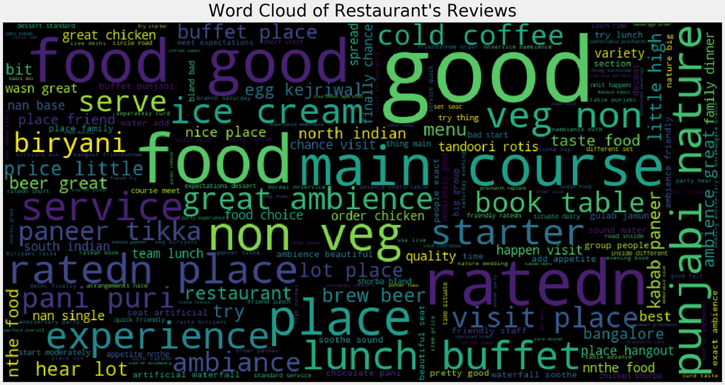

```python
plot_wordcloud(restaurant_df["extracted_reviews"], title="Word Cloud of Restaurant's Reviews")
```

**Key Takeaway:** `good`, `food` etc. are mostly written words in restaurant's reviews

### Recommendation Engine

**Input Features:**

- Reviews Text
- Location
- Budget
- Cuisine Type

**Output:**

- Restaurant 1 (90% likely)
- Restaurant 2 (84% likely)
- Restaurant 3 (81.5% likely)

#### Data Preparation for Recommendation Engine

```python
"""
Selecting Relevant Features:
"""
input_df = restaurant_df[["restaurant_id", "restaurant_name", "extracted_reviews", "location", "cost_for_two_people", "cuisines", "rating", "no_of_votes",
                          "extracted_ratings"]]

## Defining Text/Categorical/Numerical features
cat_txt_feats = ["restaurant_id", "extracted_reviews", "location", "cuisines"]
num_feats = ["cost_for_two_people", "rating", "extracted_ratings", "no_of_votes"]

## Categorical & Text Features: Fill NULL's with Blank
input_df[cat_txt_feats] = input_df[cat_txt_feats].fillna("")

## Fill Cost NULL values with Mean
input_df["cost_for_two_people"] = input_df["cost_for_two_people"].apply(lambda x: float(str(x).replace(',','')))
input_df["cost_for_two_people"] = input_df["cost_for_two_people"].fillna(np.mean(input_df["cost_for_two_people"]))

"""
Filling rating (NULL/BLANK) values with extracted_ratings and filling remaining NULL's with -1
"""
input_df["rating"] = np.where(input_df["rating"].isnull(), input_df["extracted_ratings"], input_df["rating"])
input_df["rating"] = np.round(input_df["rating"].fillna(-1),1)

## Drop extracted_ratings columns:
input_df.drop(["extracted_ratings"], axis = 1, inplace = True)
```

#### User Input Parameters

```python
"""
Define User's Inputs Here
"""
USER_LOCATION = "Jayanagar"
USER_CUISINES = "North Indian"
USER_BUDGET = 800
USER_DESCRIPTION = "good ambiance restaurants, serving fish"
USER_DESCRIPTION = gensim_clean_text(USER_DESCRIPTION) ## Clean User Description
```

#### Content Based Recommender System

Computes the similarity between restaurants based on certain parameter/metric(s) and suggests restaurants that are most similar to a particular restaurant that a user liked (user input).

As a first step, to reduce the search space, we will take user inputs (Location, Cuisines, Budget) and filter the dataset. After applying these filteres we will check the cosine similarity between User Description and Restaurant Review (Using TF-IDF vectorizer). Then, we will come up with top 3 restaurant's based on User's Input Parameter's

*Other things can be tried: Semantic based similarity between User's description and Reviews*

```python
gradient_dataframe(restaurant_recommend_func(input_df), "Top 3 Restaurant's based on User's 4 Input Parameters")
```

```
Dataset Shape after applying Location, Cuisines and Budget filters:  (18, 8)
```

Top 3 Restaurant's based on User's 4 Input Parameters

| Restaurant ID | Restaurant Name | Location | Cuisines | Cost | Rating | % Likely |
| --- | --- | --- | --- | --- | --- | --- |
| 21882 | Shanmukha | Jayanagar | Biryani, Andhra, North Indian, Chinese | 800.000000 | 4.400000 | 7.694331 |
| 2547 | Empire Restaurant | Jayanagar | North Indian, Mughlai, South Indian, Chinese | 750.000000 | 4.400000 | 7.689718 |
| 9985 | Hyderabad Bawarchi | Jayanagar | North Indian, Biryani, Chinese | 800.000000 | 3.900000 | 6.035753 |

**Key Takeaway:** `Shanmukha`, `Empire Restaurant`, `Hyderabad Bawarchi` are top 3 recommended restaurant by our algorithm based on user's input paramerters